# NAAPS / SP2 Comparison

Ella Hall

2025-09-09

# Goals of Analysis

In this script I will:

- Find times with high NAAPS smoke surface concentrations, and run summary stats on the SP2 variables for high vs. low smoke concentration time periods
- Find times with high NAAPS dust surface concentrations, and run summary stats on the SP2 variables for high vs. low smoke concentration time periods
- Find times with high NAAPS ABF surface concentrations, and run summary stats on the SP2 variables for high vs. low smoke concentration time periods

# Load the Data

**Packages**

```r
library(dplyr)
library(tidyr)
library(lubridate)
library(ggplot2)
library(scales)
library(PNWColors)
library(stringr)
library(purrr)
library(patchwork)
library(gt)
```

**Data**

*All SP2 Stats – minutely*

```r
AllStats <- read.csv("All_SP2_Statistics_Seconds.csv")
  # Drop NA rows
  AllStats <- na.omit(AllStats)

# split the `Date_Time` column to just have the date
AllStats <- AllStats %>%
  separate(Date_Time, into = c("Date", "Time_Min"), sep = " ")
head(AllStats)
```

```
##       Date Time_Min SecondsOfDay IncandParticleConc ScatteringParticleConc
## 1 20240619 00:01:01           61            4.82967                98.6885
## 2 20240619 00:02:01          121            4.54950                93.3635
## 3 20240619 00:03:01          181            4.39733                99.3720
## 4 20240619 00:04:01          241            0.00000                 0.0000
## 5 20240619 00:05:01          301            0.00000                 0.0000
## 6 20240619 00:06:01          361            4.21400                94.9780
##   IncandMassConc TotalMass dbarScatter dmvdScatter dbarIncnd dmvdIncnd
## 1        4.28333   6.60733     225.697     330.066   78.7314   247.007
## 2        2.95300   4.55583     238.343     342.402   76.2392   172.690
## 3        4.38100   6.76300     232.757     340.525   78.6810   334.639
## 4        3.72467   5.75133     225.671     320.942   76.2503   293.668
## 5        2.98500   4.60800     227.569     322.375   78.2073   154.689
## 6        2.89850   4.47283     226.820     323.994   76.1715   204.336
##   coatingTotal coatingModeEOD ambT ambWS ambWD ambRH
## 1      106.400        52.0616  6.0   2.9   338    66
## 2      100.962        53.5032  5.9   2.7   323    67
## 3      107.211        56.5070  5.8   2.2   328    68
## 4      101.756        38.5515  6.1   2.2   312    68
## 5      101.455        44.1925  5.9   2.1   308    67
## 6      102.562        54.9846  5.9   2.2   311    67
```

```r
# Clean up date format
AllStats$Date <- as.Date(as.character(AllStats$Date), format = "%Y%m%d")
```

*Flight Log*

```r
FlightLog <- read.csv("FlightData_Cleaned.csv")
```

*SP2 and Flight Log merged*

```r
SP2_FlightLogMerged <- read.csv("SP2_FlightLogMerged.csv")
```

*NAAPS Data*

```r
Pituffik_NAAPS <- read.csv("Pituffik_SP2_NAAPS_Data.csv")
# Clean up date format
Pituffik_NAAPS$Date <- as.Date(Pituffik_NAAPS$Date)

Pituffik_SurfConc <- read.csv("PituffikSurfaceConcentrations_SP2.csv")
Pituffik_SurfConc$Date <- as.Date(Pituffik_SurfConc$Date)
```

# NAAPS Data Exploration

I will start by plotting smoke, dust and ABF over the time period of the dataset to get an idea of when there may have been high deposition events. I will identify time periods when there were elevated concentrations

## Smoke

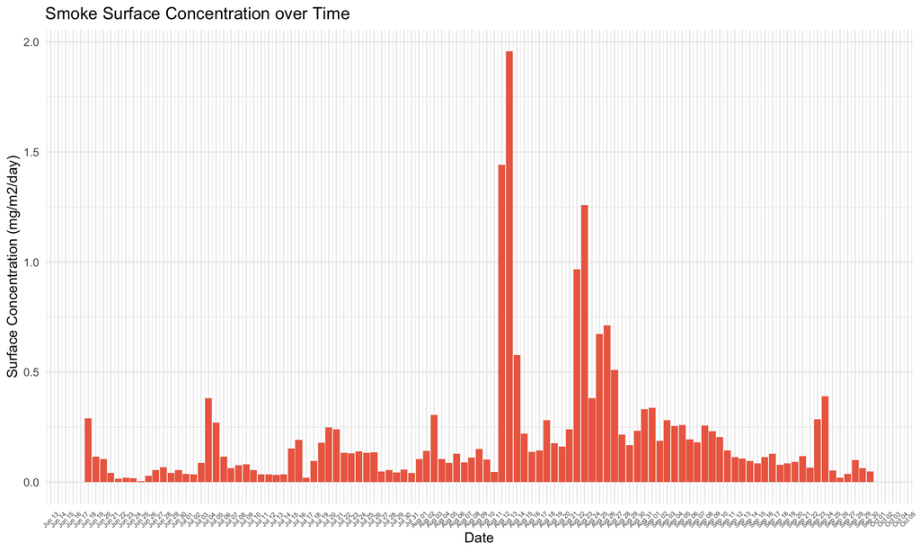

```r
ggplot(Pituffik_SurfConc, aes(x = Date, y = smoke_conc_sfc)) +
  geom_bar(stat = "identity", fill = "coral2") +
  scale_x_date(date_breaks = "1 day", date_labels = "%b %d") +
  labs(
    title = "Smoke Surface Concentration over Time",
    x = "Date",
    y = "Surface Concentration (mg/m2/day)"
  ) +
  theme_minimal() +
  theme(axis.text.x = element_text(angle = 45, vjust = 0.5, size = 5))
```

It looks like smoke surface concentrations were highest in the second half of the study period. The highest smoke events were August 11 and 12th.

```r
summary(Pituffik_SurfConc$smoke_conc_sfc)
```

```
##    Min. 1st Qu.  Median    Mean 3rd Qu.    Max.
## 0.00409 0.05716 0.11667 0.20025 0.23220 1.95804
```

I will use the median value as the threshold to flag time periods of events that are higher than that value.

```r
# Calculate threshold per year
Pituffik_SurfConc <- Pituffik_SurfConc %>%
  mutate(
    SmokeThreshold = median(smoke_conc_sfc),
    SmokeEvent = smoke_conc_sfc >= SmokeThreshold  # Identify exceedance
  ) %>%
  ungroup()
```

I just want to visually check that the baseline threshold is looking how I would expect for each year.

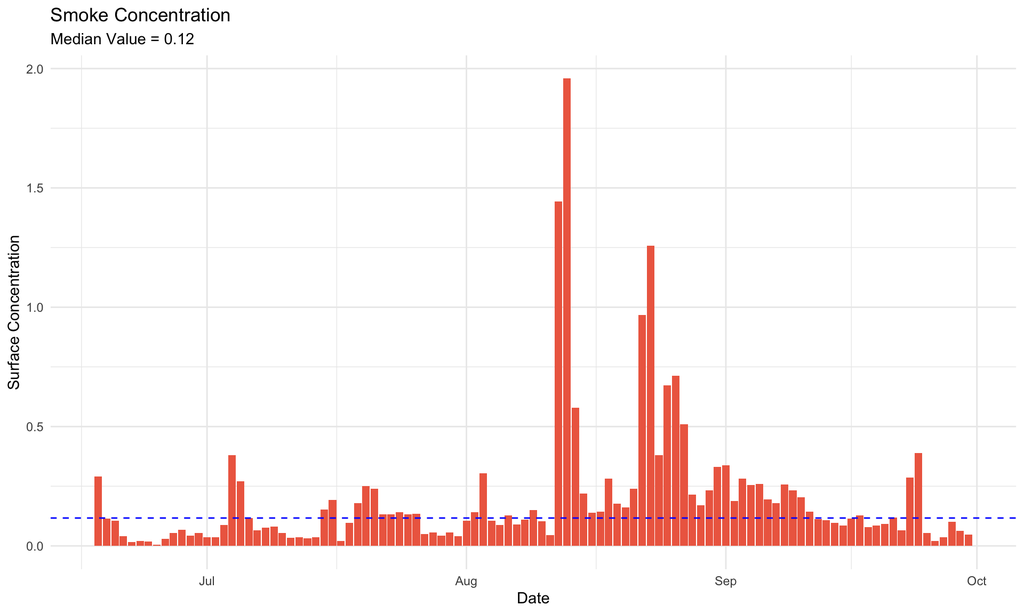

```r
# If you want a single global threshold (not per year)
smoke_threshold_value <- with(Pituffik_SurfConc, median(smoke_conc_sfc))

ggplot(Pituffik_SurfConc, aes(x = Date, y = smoke_conc_sfc)) +
  geom_bar(stat = "identity", fill = "coral2") +
  geom_hline(yintercept = smoke_threshold_value, color = "blue", linetype = "dashed") +
  labs(
    title = "Smoke Concentration",
    subtitle = paste("Median Value =", round(smoke_threshold_value, 2)),
    y = "Surface Concentration",
    x = "Date"
  ) +
  theme_minimal()
```

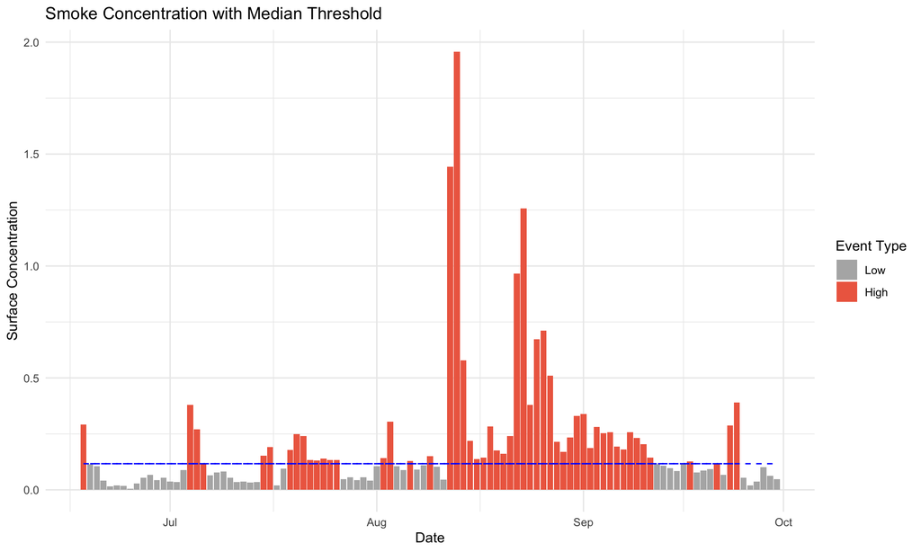

```r
ggplot(Pituffik_SurfConc, aes(x = Date, y = smoke_conc_sfc, fill = SmokeEvent)) +
  geom_col() +
  geom_line(aes(y = SmokeThreshold), color = "blue", linetype = "dashed") +
  scale_fill_manual(values = c("FALSE" = "gray70", "TRUE" = "coral2"),
                    name = "Event Type",
                    labels = c("Low", "High")) +
  labs(
    title = "Smoke Concentration with Median Threshold",
    y = "Surface Concentration",
    x = "Date"
  ) +
  theme_minimal()
```

## Dust

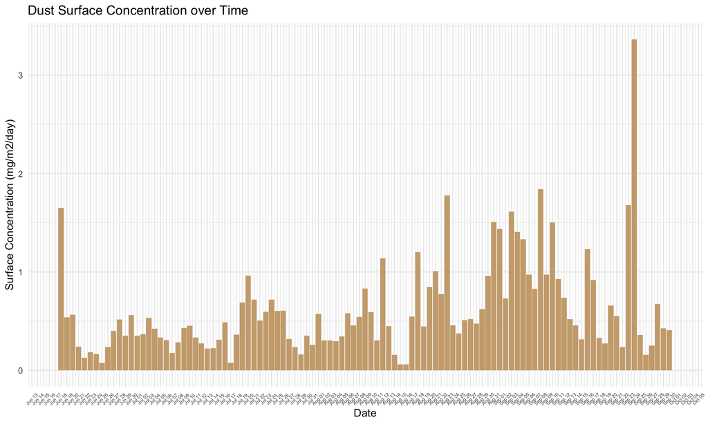

```r
ggplot(Pituffik_SurfConc, aes(x = Date, y = dust_conc_sfc)) +
  geom_bar(stat = "identity", fill = "burlywood3") +
  scale_x_date(date_breaks = "1 day", date_labels = "%b %d") +
  labs(
    title = "Dust Surface Concentration over Time",
    x = "Date",
    y = "Surface Concentration (mg/m2/day)"
  ) +
  theme_minimal() +
  theme(axis.text.x = element_text(angle = 45, vjust = 0.5, size = 5))
```

Dust concentrations were generally much higher than smoke concentrations. Dust deposition was also generally higher during the later half of the study period. There was a very high dust deposition event on September 23rd.

```r
summary(Pituffik_SurfConc$dust_conc_sfc)
```

```
##    Min. 1st Qu.  Median    Mean 3rd Qu.    Max.
## 0.05906 0.30590 0.47408 0.61364 0.72961 3.36509
```

I will use the median value as the threshold to flag time periods of events that are higher than that value.

```r
# Calculate threshold per year
Pituffik_SurfConc <- Pituffik_SurfConc %>%
  mutate(
    DustThreshold = median(dust_conc_sfc),
    DustEvent = dust_conc_sfc >= DustThreshold  # Identify exceedance
  ) %>%
  ungroup()
```

I just want to visually check that the baseline threshold is looking how I would expect for each year.

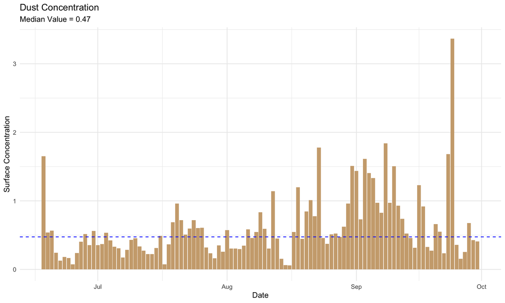

```r
# If you want a single global threshold (not per year)
dust_threshold_value <- with(Pituffik_SurfConc, median(dust_conc_sfc))

ggplot(Pituffik_SurfConc, aes(x = Date, y = dust_conc_sfc)) +
  geom_bar(stat = "identity", fill = "burlywood3") +
  geom_hline(yintercept = dust_threshold_value, color = "blue", linetype = "dashed") +
  labs(
    title = "Dust Concentration",
    subtitle = paste("Median Value =", round(dust_threshold_value, 2)),
    y = "Surface Concentration",
    x = "Date"
  ) +
  theme_minimal()
```

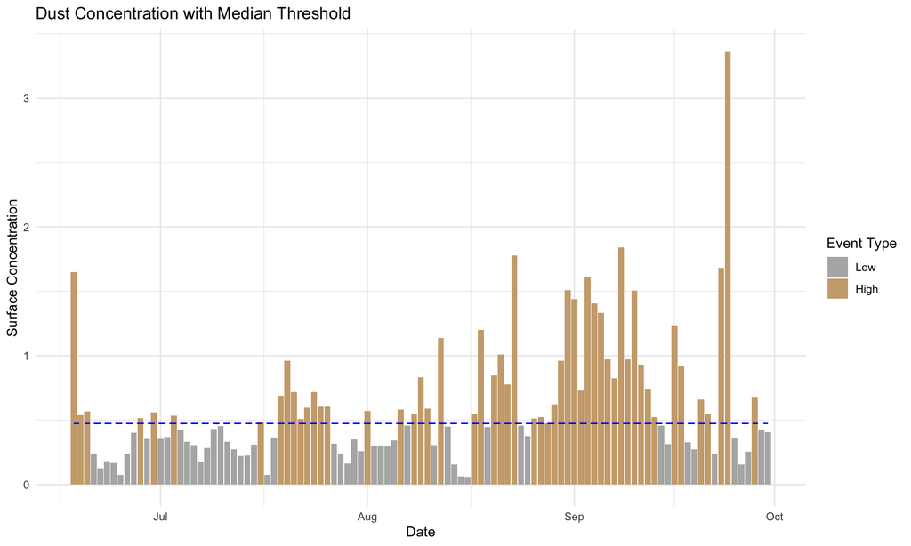

```r
ggplot(Pituffik_SurfConc, aes(x = Date, y = dust_conc_sfc, fill = DustEvent)) +
  geom_col() +
  geom_line(aes(y = DustThreshold), color = "blue", linetype = "dashed") +
  scale_fill_manual(values = c("FALSE" = "gray70", "TRUE" = "burlywood3"),
                    name = "Event Type",
                    labels = c("Low", "High")) +
  labs(
    title = "Dust Concentration with Median Threshold",
    y = "Surface Concentration",
    x = "Date"
  ) +
  theme_minimal()
```

## ABF

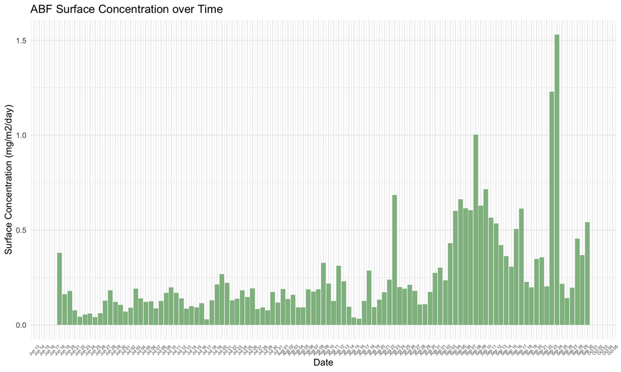

```r
ggplot(Pituffik_SurfConc, aes(x = Date, y = abf_conc_sfc)) +
  geom_bar(stat = "identity", fill = "darkseagreen") +
  scale_x_date(date_breaks = "1 day", date_labels = "%b %d") +
  labs(
    title = "ABF Surface Concentration over Time",
    x = "Date",
    y = "Surface Concentration (mg/m2/day)"
  ) +
  theme_minimal() +
  theme(axis.text.x = element_text(angle = 45, vjust = 0.5, size = 5))
```

ABF looks like it follows a more similar pattern to dust than smoke. The highest ABF concentration was also on September 23rd.

```r
summary(Pituffik_SurfConc$abf_conc_sfc)
```

```
##    Min. 1st Qu.  Median    Mean 3rd Qu.    Max.
##  0.0293  0.1185  0.1787  0.2543  0.3018  1.5306
```

I will use the median value as the threshold to flag time periods of events that are higher than that value.

```r
# Calculate threshold per year
Pituffik_SurfConc <- Pituffik_SurfConc %>%
  mutate(
    ABFThreshold = median(abf_conc_sfc),
    ABFEvent = abf_conc_sfc >= ABFThreshold  # Identify exceedance
  ) %>%
  ungroup()
```

I just want to visually check that the baseline threshold is looking how I would expect for each year.

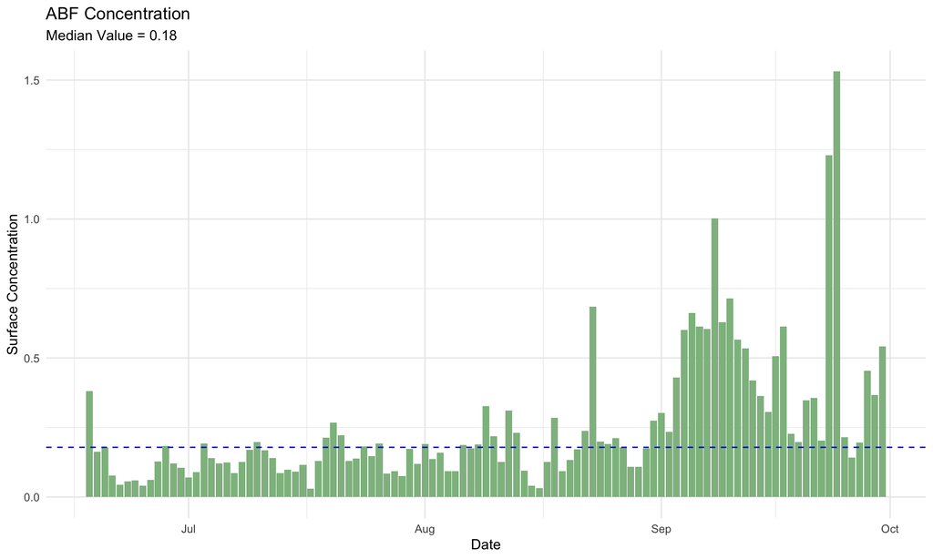

```r
# If you want a single global threshold (not per year)
abf_threshold_value <- with(Pituffik_SurfConc, median(abf_conc_sfc))

ggplot(Pituffik_SurfConc, aes(x = Date, y = abf_conc_sfc)) +
  geom_bar(stat = "identity", fill = "darkseagreen") +
  geom_hline(yintercept = abf_threshold_value, color = "blue", linetype = "dashed") +
  labs(
    title = "ABF Concentration",
    subtitle = paste("Median Value =", round(abf_threshold_value, 2)),
    y = "Surface Concentration",
    x = "Date"
  ) +
  theme_minimal()
```

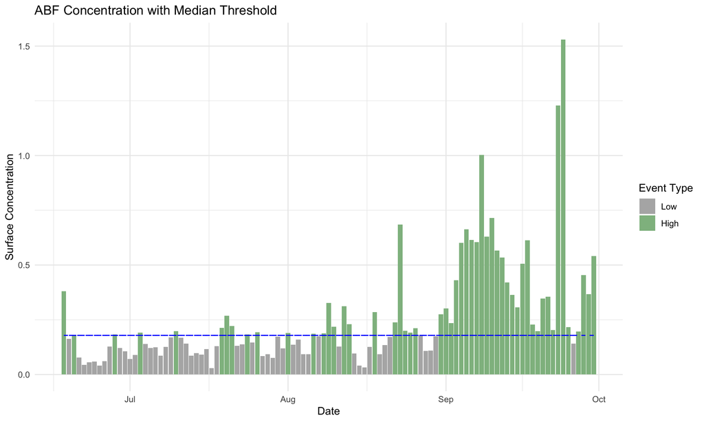

```r
ggplot(Pituffik_SurfConc, aes(x = Date, y = abf_conc_sfc, fill = ABFEvent)) +
  geom_col() +
  geom_line(aes(y = ABFThreshold), color = "blue", linetype = "dashed") +
  scale_fill_manual(values = c("FALSE" = "gray70", "TRUE" = "darkseagreen"),
                    name = "Event Type",
                    labels = c("Low", "High")) +
  labs(
    title = "ABF Concentration with Median Threshold",
    y = "Surface Concentration",
    x = "Date"
  ) +
  theme_minimal()
```

# SP2 Data Exploration and Summary Stats

```r
DailySP2 <- SP2_FlightLogMerged %>%
mutate(
    DateTime = as.POSIXct(paste(Date, Time_Min), format = "%Y-%m-%d %H:%M:%S"))
```

```r
DailySP2 <- DailySP2 %>%
  group_by(Date) %>%
  summarize(
    DailyIncandParticle = mean(IncandParticleConc, na.rm = TRUE),
    DailyIncandMass = mean(IncandMassConc, na.rm = TRUE),
    DailyTotMass = mean(TotalMass, na.rm = TRUE),
    DailyCoating = mean(coatingModeEOD, na.rm = TRUE))

# convert to date format
DailySP2$Date <- as.Date(DailySP2$Date)
```

Then, I will merge this with the NAAPS data:

```r
DailySP2_NAAPS_Sfc <- left_join(DailySP2, Pituffik_SurfConc, by = c("Date"))
```

Now, I can look at summary stats of each variable during high vs. low events for each deposition type.

## Smoke Events

I will start by looking at summary stats during high vs. low smoke events:

```r
DailySP2_NAAPS_Sfc %>%
  group_by(SmokeEvent) %>% # group by high and low events
  summarise(
    mean_IncandParticle = mean(DailyIncandParticle),
    median_IncandParticle = median(DailyIncandParticle),
    sd_IncandParticle = sd(DailyIncandParticle),
    mean_IncandMass = mean(DailyIncandMass),
    median_IncandMass = median(DailyIncandMass),
    sd_IncandMass = sd(DailyIncandMass),
    mean_TotMass = mean(DailyTotMass),
    median_TotMass = median(DailyTotMass),
    sd_TotMass = sd(DailyTotMass),
    mean_Coating = mean(DailyCoating),
    median_Coating = median(DailyCoating),
    sd_Coating = sd(DailyCoating)
  ) %>%
  mutate(SmokeEvent = ifelse(SmokeEvent, "High", "Low")) %>%

  # format into a nice table
    gt() %>%
  tab_header(
    title = "Summary Stats: High vs. Low Smoke Events") %>%
  fmt_number(
    columns = where(is.numeric), decimals = 2
  )
```

Summary Stats: High vs. Low Smoke Events

| SmokeEvent | mean_IncandParticle | median_IncandParticle | sd_IncandParticle | mean_IncandMass | median_IncandMass | sd_IncandMass | mean_TotMass | median_TotMass | sd_TotMass | mean_Coating | median_Coating | sd_Coating |
| --- | --- | --- | --- | --- | --- | --- | --- | --- | --- | --- | --- | --- |
| Low | 5.85 | 3.19 | 7.29 | 3.74 | 2.08 | 6.55 | 6.74 | 4.00 | 10.09 | 56.20 | 56.66 | 3.67 |
| High | 4.94 | 3.40 | 6.75 | 2.69 | 1.98 | 2.74 | 5.09 | 4.40 | 4.09 | 61.06 | 59.69 | 9.98 |

## Dust Events

I will start by looking at summary stats during high vs. low dust events:

```r
DailySP2_NAAPS_Sfc %>%
  group_by(DustEvent) %>% # group by high and low events
  summarise(
    mean_IncandParticle = mean(DailyIncandParticle),
    median_IncandParticle = median(DailyIncandParticle),
    sd_IncandParticle = sd(DailyIncandParticle),
    mean_IncandMass = mean(DailyIncandMass),
    median_IncandMass = median(DailyIncandMass),
    sd_IncandMass = sd(DailyIncandMass),
    mean_TotMass = mean(DailyTotMass),
    median_TotMass = median(DailyTotMass),
    sd_TotMass = sd(DailyTotMass),
    mean_Coating = mean(DailyCoating),
    median_Coating = median(DailyCoating),
    sd_Coating = sd(DailyCoating)
  ) %>%
  mutate(DustEvent = ifelse(DustEvent, "High", "Low")) %>%

  # format into a nice table
    gt() %>%
  tab_header(
    title = "Summary Stats: High vs. Low Dust Events") %>%
  fmt_number(
    columns = where(is.numeric), decimals = 2
  )
```

Summary Stats: High vs. Low Dust Events

| DustEvent | mean_IncandParticle | median_IncandParticle | sd_IncandParticle | mean_IncandMass | median_IncandMass | sd_IncandMass | mean_TotMass | median_TotMass | sd_TotMass | mean_Coating | median_Coating | sd_Coating |
| --- | --- | --- | --- | --- | --- | --- | --- | --- | --- | --- | --- | --- |
| Low | 6.06 | 2.78 | 9.12 | 3.65 | 1.78 | 6.80 | 6.58 | 3.74 | 10.48 | 56.70 | 56.19 | 4.00 |
| High | 4.75 | 4.26 | 3.98 | 2.80 | 2.79 | 2.27 | 5.27 | 5.34 | 3.32 | 60.47 | 58.71 | 10.01 |

## ABF Events

I will start by looking at summary stats during high vs. low ABF events:

```r
DailySP2_NAAPS_Sfc %>%
  group_by(ABFEvent) %>% # group by high and low events
  summarise(
    mean_IncandParticle = mean(DailyIncandParticle),
    median_IncandParticle = median(DailyIncandParticle),
    sd_IncandParticle = sd(DailyIncandParticle),
    mean_IncandMass = mean(DailyIncandMass),
    median_IncandMass = median(DailyIncandMass),
    sd_IncandMass = sd(DailyIncandMass),
    mean_TotMass = mean(DailyTotMass),
    median_TotMass = median(DailyTotMass),
    sd_TotMass = sd(DailyTotMass),
    mean_Coating = mean(DailyCoating),
    median_Coating = median(DailyCoating),
    sd_Coating = sd(DailyCoating)
  ) %>%
  mutate(ABFEvent = ifelse(ABFEvent, "High", "Low")) %>%

  # format into a nice table
    gt() %>%
  tab_header(
    title = "Summary Stats: High vs. Low ABF Events") %>%
  fmt_number(
    columns = where(is.numeric), decimals = 2
  )
```

Summary Stats: High vs. Low ABF Events

| ABFEvent | mean_IncandParticle | median_IncandParticle | sd_IncandParticle | mean_IncandMass | median_IncandMass | sd_IncandMass | mean_TotMass | median_TotMass | sd_TotMass | mean_Coating | median_Coating | sd_Coating |
| --- | --- | --- | --- | --- | --- | --- | --- | --- | --- | --- | --- | --- |
| Low | 5.16 | 2.76 | 7.58 | 3.38 | 1.61 | 6.73 | 6.13 | 3.53 | 10.40 | 57.61 | 57.19 | 3.66 |
| High | 5.63 | 4.20 | 6.47 | 3.06 | 2.65 | 2.53 | 5.72 | 4.93 | 3.67 | 59.59 | 57.89 | 10.39 |

# Summary Stats

I will organize the SP2 by NAAPS separation. High and low smoke, high and low dust, high and low ABF.

## Smoke

*High smoke times*

```r
HighSmoke_SP2 <- DailySP2_NAAPS_Sfc %>%
  filter(SmokeEvent == TRUE)
```

*Low smoke times*

```r
LowSmoke_SP2 <- DailySP2_NAAPS_Sfc %>%
  filter(SmokeEvent == FALSE)
```

Then I will plot the four variables of interest during high and low smoke events: *Incandescent particle concentration*

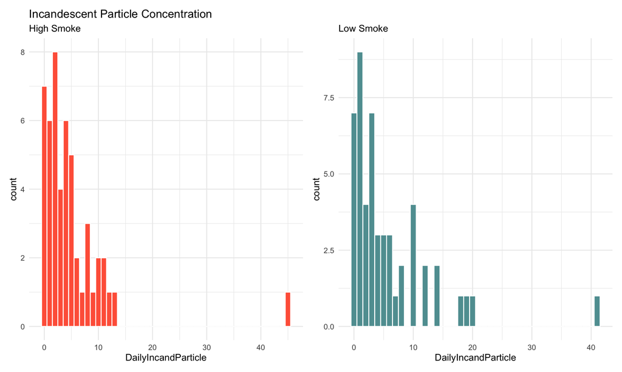

```r
HighSmoke_IncandPart <- ggplot(HighSmoke_SP2, aes(x = DailyIncandParticle)) +
  geom_histogram(binwidth = 1, fill = "tomato", color = "white") +
  theme_minimal() +
  labs(title = "Incandescent Particle Concentration",
       subtitle = "High Smoke")


LowSmoke_IncandPart <- ggplot(LowSmoke_SP2, aes(x = DailyIncandParticle)) +
  geom_histogram(binwidth = 1, fill = "cadetblue", color = "white") +
  theme_minimal()  +
  labs(subtitle = "Low Smoke")


library(patchwork)
HighSmoke_IncandPart + LowSmoke_IncandPart
```

Most of the time, both high and low smoke periods have concentrations below 10. There are extreme events above 40 during both high and low periods.

I can compare the mean and medians between high and low smoke events:

```r
# Means and medians
HighSmoke_IncandSummary <- HighSmoke_SP2 %>%
  summarise(
    mean_high = mean(DailyIncandParticle, na.rm = TRUE),
    median_high = median(DailyIncandParticle, na.rm = TRUE)
  )

LowSmoke_IncandSummary <- LowSmoke_SP2 %>%
  summarise(
    mean_low = mean(DailyIncandParticle, na.rm = TRUE),
    median_low = median(DailyIncandParticle, na.rm = TRUE)
  )

HighSmoke_IncandSummary
```

```
## # A tibble: 1 × 2
##   mean_high median_high
##       <dbl>       <dbl>
## 1      4.94        3.40
```

```r
LowSmoke_IncandSummary
```

```
## # A tibble: 1 × 2
##   mean_low median_low
##      <dbl>      <dbl>
## 1     5.85       3.19
```

Mean high: 4.93 Mean low: 5.847

Median high: 3.395 Median low: 3.1855

The mean is actually higher during low events, but the median is slightly higher during high events. The median makes more sense given the non-normal distirbution.

I will also run a wilcoxon test to determine if incandescent particle concentration differs significantly between high and low events:

```r
Smoke_Wilcoxon_IncandParticle <- wilcox.test(
  HighSmoke_SP2$DailyIncandParticle,
  LowSmoke_SP2$DailyIncandParticle,
  alternative = "two.sided"  # or "greater"/"less" if you expect direction
)

Smoke_Wilcoxon_IncandParticle
```

```
##
##  Wilcoxon rank sum test with continuity correction
##
## data:  HighSmoke_SP2$DailyIncandParticle and LowSmoke_SP2$DailyIncandParticle
## W = 1225, p-value = 0.7367
## alternative hypothesis: true location shift is not equal to 0
```

There is not a significant difference in incandescent particle concentration between high and low smoke deposition times.

*Incandescent Mass*

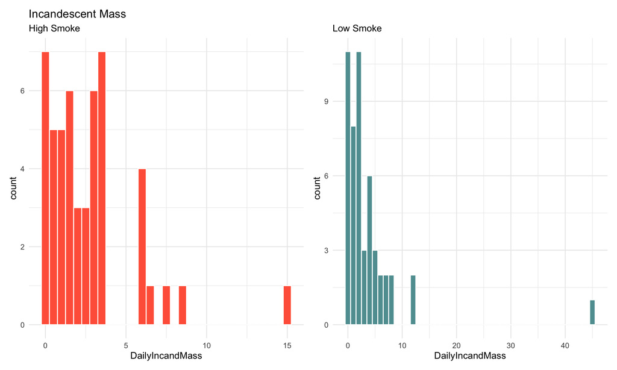

```r
HighSmoke_IncandMass <- ggplot(HighSmoke_SP2, aes(x = DailyIncandMass)) +
  geom_histogram(binwidth = 0.5, fill = "tomato", color = "white") +
  theme_minimal() +
  labs(title = "Incandescent Mass",
       subtitle = "High Smoke")


LowSmoke_IncandMass <- ggplot(LowSmoke_SP2, aes(x = DailyIncandMass)) +
  geom_histogram(binwidth = 1, fill = "cadetblue", color = "white") +
  theme_minimal()  +
  labs(subtitle = "Low Smoke")


HighSmoke_IncandMass + LowSmoke_IncandMass
```

The incandescent mass concentration looks pretty similar between high and low events as well. There is a really high outlier past 40 in the low smoke events.

I can compare the mean and medians between high and low smoke events:

```r
# Means and medians
HighSmoke_IncandMassSummary <- HighSmoke_SP2 %>%
  summarise(
    mean_high = mean(DailyIncandMass, na.rm = TRUE),
    median_high = median(DailyIncandMass, na.rm = TRUE)
  )

LowSmoke_IncandMassSummary <- LowSmoke_SP2 %>%
  summarise(
    mean_low = mean(DailyIncandMass, na.rm = TRUE),
    median_low = median(DailyIncandMass, na.rm = TRUE)
  )

HighSmoke_IncandMassSummary
```

```
## # A tibble: 1 × 2
##   mean_high median_high
##       <dbl>       <dbl>
## 1      2.69        1.98
```

```r
LowSmoke_IncandMassSummary
```

```
## # A tibble: 1 × 2
##   mean_low median_low
##      <dbl>      <dbl>
## 1     3.74       2.08
```

Mean high: 2.69 Mean low: 3.74

Median high: 1.97 Median low: 2.08

The mean and median are actually higher during low events. This is the opposite of what I would expect.

I will also run a wilcoxon test to determine if incandescent mass concentration differs significantly between high and low events:

```r
Smoke_Wilcoxon_IncandMass <- wilcox.test(
  HighSmoke_SP2$DailyIncandMass,
  LowSmoke_SP2$DailyIncandMass,
  alternative = "two.sided"  # or "greater"/"less" if you expect direction
)

Smoke_Wilcoxon_IncandMass
```

```
##
##  Wilcoxon rank sum test with continuity correction
##
## data:  HighSmoke_SP2$DailyIncandMass and LowSmoke_SP2$DailyIncandMass
## W = 1212, p-value = 0.6712
## alternative hypothesis: true location shift is not equal to 0
```

There is not a significant difference in incandescent mass concentration between high and low smoke deposition times.

*Total Mass*

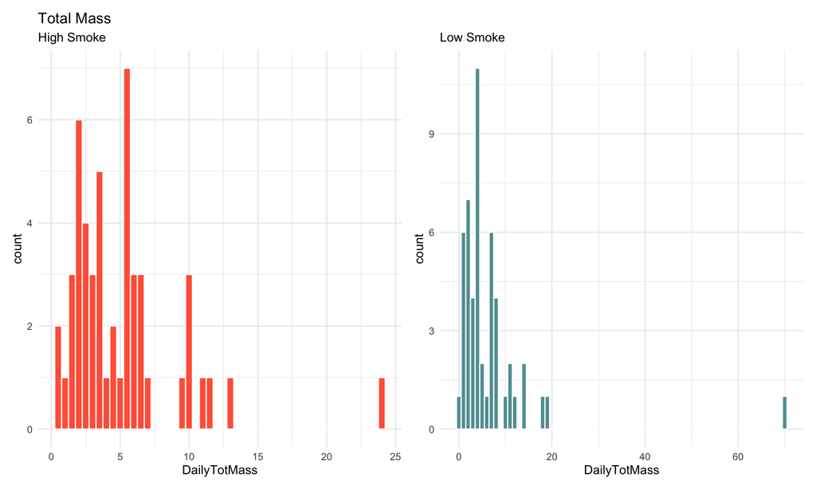

```r
HighSmoke_TotalMass <- ggplot(HighSmoke_SP2, aes(x = DailyTotMass)) +
  geom_histogram(binwidth = 0.5, fill = "tomato", color = "white") +
  theme_minimal() +
  labs(title = "Total Mass",
       subtitle = "High Smoke")


LowSmoke_TotalMass <- ggplot(LowSmoke_SP2, aes(x = DailyTotMass)) +
  geom_histogram(binwidth = 1, fill = "cadetblue", color = "white") +
  theme_minimal()  +
  labs(subtitle = "Low Smoke")


HighSmoke_TotalMass + LowSmoke_TotalMass
```

Looks like the total mass was generally lower during high smoke events? There is a high outlier during the low smoke times.

I can compare the mean and medians between high and low smoke events:

```r
# Means and medians
HighSmoke_TotalMassSummary <- HighSmoke_SP2 %>%
  summarise(
    mean_high = mean(DailyTotMass, na.rm = TRUE),
    median_high = median(DailyTotMass, na.rm = TRUE)
  )

LowSmoke_TotalMassSummary <- LowSmoke_SP2 %>%
  summarise(
    mean_low = mean(DailyTotMass, na.rm = TRUE),
    median_low = median(DailyTotMass, na.rm = TRUE)
  )

HighSmoke_TotalMassSummary
```

```
## # A tibble: 1 × 2
##   mean_high median_high
##       <dbl>       <dbl>
## 1      5.09        4.40
```

```r
LowSmoke_TotalMassSummary
```

```
## # A tibble: 1 × 2
##   mean_low median_low
##      <dbl>      <dbl>
## 1     6.74       4.00
```

Mean high: 5.08 Mean low: 6.74

Median high: 4.396 Median low: 3.99

I will also run a wilcoxon test to determine if total mass differs significantly between high and low events:

```r
Smoke_Wilcoxon_TotMass <- wilcox.test(
  HighSmoke_SP2$DailyTotMass,
  LowSmoke_SP2$DailyTotMass,
  alternative = "two.sided"  # or "greater"/"less" if you expect direction
)

Smoke_Wilcoxon_TotMass
```

```
##
##  Wilcoxon rank sum test with continuity correction
##
## data:  HighSmoke_SP2$DailyTotMass and LowSmoke_SP2$DailyTotMass
## W = 1206, p-value = 0.6417
## alternative hypothesis: true location shift is not equal to 0
```

There is not a significant difference in incandescent mass concentration between high and low smoke deposition times.

*Coating Total*

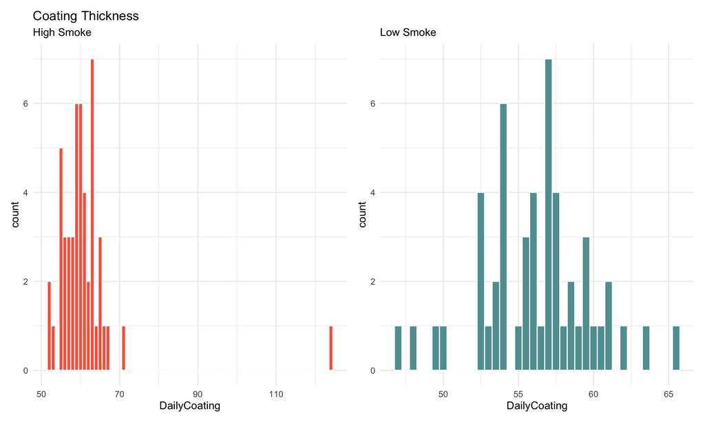

```r
HighSmoke_Coating <- ggplot(HighSmoke_SP2, aes(x = DailyCoating)) +
  geom_histogram(binwidth = 1, fill = "tomato", color = "white") +
  theme_minimal() +
  labs(title = "Coating Thickness",
       subtitle = "High Smoke")


LowSmoke_Coating <- ggplot(LowSmoke_SP2, aes(x = DailyCoating)) +
  geom_histogram(binwidth = 0.5, fill = "cadetblue", color = "white") +
  theme_minimal()  +
  labs(subtitle = "Low Smoke")


HighSmoke_Coating + LowSmoke_Coating
```

Coating thickness seems to follow a fairly normal distribution with one very high outlier in the high smoke category.

I can compare the mean and medians between high and low smoke events:

```r
# Means and medians
HighSmoke_CoatingSummary <- HighSmoke_SP2 %>%
  summarise(
    mean_high = mean(DailyCoating, na.rm = TRUE),
    median_high = median(DailyCoating, na.rm = TRUE)
  )

LowSmoke_CoatingSummary <- LowSmoke_SP2 %>%
  summarise(
    mean_low = mean(DailyCoating, na.rm = TRUE),
    median_low = median(DailyCoating, na.rm = TRUE)
  )

HighSmoke_CoatingSummary
```

```
## # A tibble: 1 × 2
##   mean_high median_high
##       <dbl>       <dbl>
## 1      61.1        59.7
```

```r
LowSmoke_CoatingSummary
```

```
## # A tibble: 1 × 2
##   mean_low median_low
##      <dbl>      <dbl>
## 1     56.2       56.7
```

Mean high: 61.06 Mean low: 56.19

Median high: 59.69 Median low: 56.65

The mean and median are higher during high events. This is what I would expect.

I will also run a wilcoxon test to determine if total mass differs significantly between high and low events:

```r
Smoke_Wilcoxon_Coating <- wilcox.test(
  HighSmoke_SP2$DailyCoating,
  LowSmoke_SP2$DailyCoating,
  alternative = "two.sided"  # or "greater"/"less" if you expect direction
)

Smoke_Wilcoxon_Coating
```

```
##
##  Wilcoxon rank sum test with continuity correction
##
## data:  HighSmoke_SP2$DailyCoating and LowSmoke_SP2$DailyCoating
## W = 1915, p-value = 1.401e-05
## alternative hypothesis: true location shift is not equal to 0
```

There IS a significant difference in the coating total between high and low smoke events (p < 0.001). The coating thickness is larger during high smoke events.

## Dust

*High Dust times*

```r
HighDust_SP2 <- DailySP2_NAAPS_Sfc %>%
  filter(DustEvent == TRUE)
```

*Low Dust times*

```r
LowDust_SP2 <- DailySP2_NAAPS_Sfc %>%
  filter(DustEvent == FALSE)
```

Then I will plot the four variables of interest during high and low Dust events: *Incandescent particle concentration*

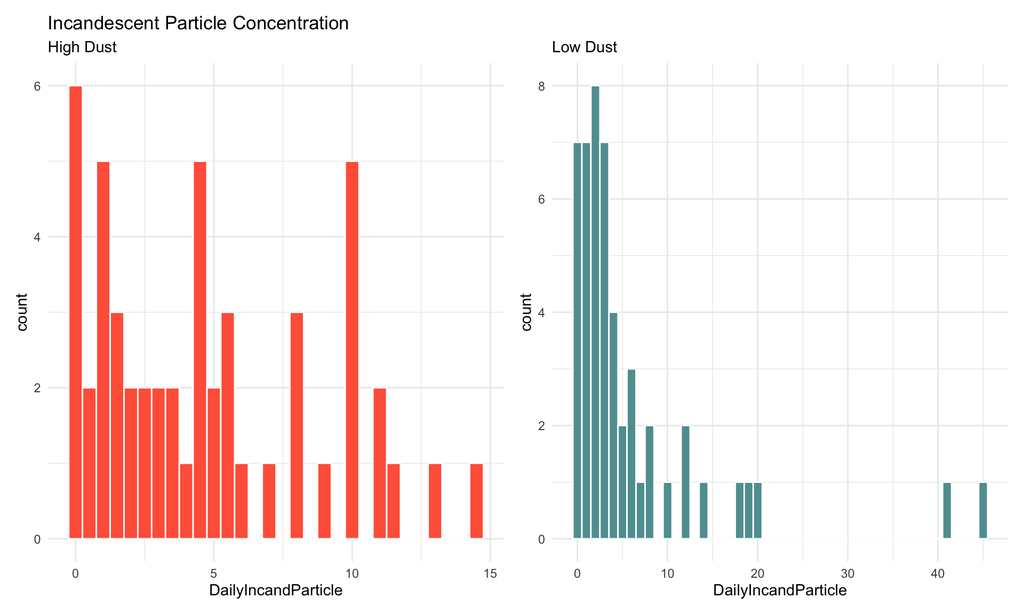

```r
HighDust_IncandPart <- ggplot(HighDust_SP2, aes(x = DailyIncandParticle)) +
  geom_histogram(binwidth = 0.5, fill = "tomato", color = "white") +
  theme_minimal() +
  labs(title = "Incandescent Particle Concentration",
       subtitle = "High Dust")


LowDust_IncandPart <- ggplot(LowDust_SP2, aes(x = DailyIncandParticle)) +
  geom_histogram(binwidth = 1, fill = "cadetblue", color = "white") +
  theme_minimal()  +
  labs(subtitle = "Low Dust")


HighDust_IncandPart + LowDust_IncandPart
```

It seems like the incandescent particle concentrations are higher during low dust events? There are more high outliers.

I can compare the mean and medians between high and low Dust events:

```r
# Means and medians
HighDust_IncandSummary <- HighDust_SP2 %>%
  summarise(
    mean_high = mean(DailyIncandParticle, na.rm = TRUE),
    median_high = median(DailyIncandParticle, na.rm = TRUE)
  )

LowDust_IncandSummary <- LowDust_SP2 %>%
  summarise(
    mean_low = mean(DailyIncandParticle, na.rm = TRUE),
    median_low = median(DailyIncandParticle, na.rm = TRUE)
  )

HighDust_IncandSummary
```

```
## # A tibble: 1 × 2
##   mean_high median_high
##       <dbl>       <dbl>
## 1      4.75        4.26
```

```r
LowDust_IncandSummary
```

```
## # A tibble: 1 × 2
##   mean_low median_low
##      <dbl>      <dbl>
## 1     6.06       2.78
```

Mean high: 4.75 Mean low: 6.06

Median high: 4.26 Median low: 2.78

The mean is higher during low events, but the median is higher during high events.

I will also run a wilcoxon test to determine if incandescent particle concentration differs significantly between high and low events:

```r
Dust_Wilcoxon_IncandParticle <- wilcox.test(
  HighDust_SP2$DailyIncandParticle,
  LowDust_SP2$DailyIncandParticle,
  alternative = "two.sided"  # or "greater"/"less" if you expect direction
)

Dust_Wilcoxon_IncandParticle
```

```
##
##  Wilcoxon rank sum test with continuity correction
##
## data:  HighDust_SP2$DailyIncandParticle and LowDust_SP2$DailyIncandParticle
## W = 1339, p-value = 0.6662
## alternative hypothesis: true location shift is not equal to 0
```

There is not a significant difference in incandescent particle concentration between high and low Dust deposition times.

*Incandescent Mass*

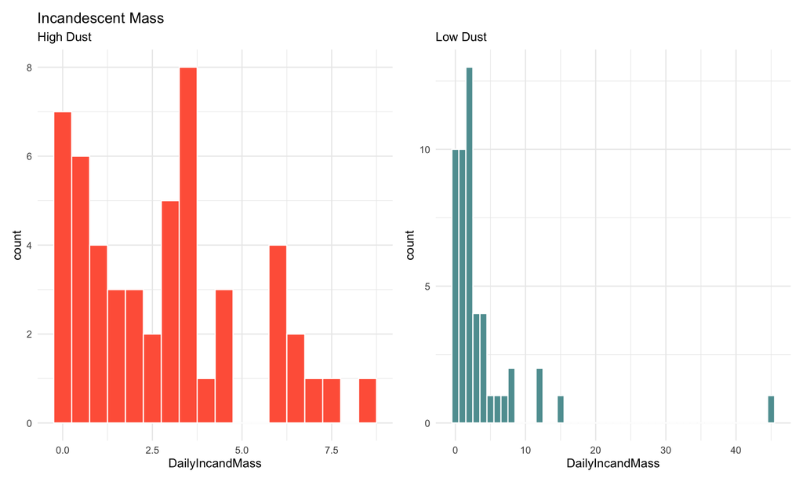

```r
HighDust_IncandMass <- ggplot(HighDust_SP2, aes(x = DailyIncandMass)) +
  geom_histogram(binwidth = 0.5, fill = "tomato", color = "white") +
  theme_minimal() +
  labs(title = "Incandescent Mass",
       subtitle = "High Dust")


LowDust_IncandMass <- ggplot(LowDust_SP2, aes(x = DailyIncandMass)) +
  geom_histogram(binwidth = 1, fill = "cadetblue", color = "white") +
  theme_minimal()  +
  labs(subtitle = "Low Dust")


HighDust_IncandMass + LowDust_IncandMass
```

The incandescent mass concentration looks pretty similar between high and low events as well. There is a really high outlier past 40 in the low Dust events.

I can compare the mean and medians between high and low Dust events:

```r
# Means and medians
HighDust_IncandMassSummary <- HighDust_SP2 %>%
  summarise(
    mean_high = mean(DailyIncandMass, na.rm = TRUE),
    median_high = median(DailyIncandMass, na.rm = TRUE)
  )

LowDust_IncandMassSummary <- LowDust_SP2 %>%
  summarise(
    mean_low = mean(DailyIncandMass, na.rm = TRUE),
    median_low = median(DailyIncandMass, na.rm = TRUE)
  )

HighDust_IncandMassSummary
```

```
## # A tibble: 1 × 2
##   mean_high median_high
##       <dbl>       <dbl>
## 1      2.80        2.79
```

```r
LowDust_IncandMassSummary
```

```
## # A tibble: 1 × 2
##   mean_low median_low
##      <dbl>      <dbl>
## 1     3.65       1.78
```

Mean high: 2.79 Mean low: 3.65

Median high: 2.78 Median low: 1.77

The mean is higher during low events, but the median is higher during high events.

I will also run a wilcoxon test to determine if incandescent mass concentration differs significantly between high and low events:

```r
Dust_Wilcoxon_IncandMass <- wilcox.test(
  HighDust_SP2$DailyIncandMass,
  LowDust_SP2$DailyIncandMass,
  alternative = "two.sided"  # or "greater"/"less" if you expect direction
)

Dust_Wilcoxon_IncandMass
```

```
##
##  Wilcoxon rank sum test with continuity correction
##
## data:  HighDust_SP2$DailyIncandMass and LowDust_SP2$DailyIncandMass
## W = 1372, p-value = 0.5122
## alternative hypothesis: true location shift is not equal to 0
```

There is not a significant difference in incandescent mass concentration between high and low Dust deposition times.

*Total Mass*

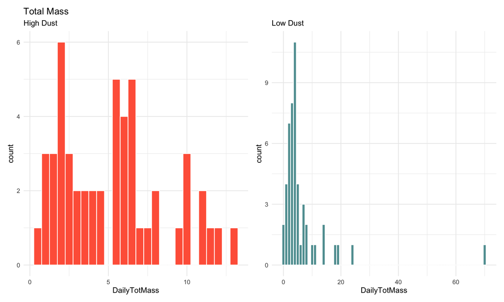

```r
HighDust_TotalMass <- ggplot(HighDust_SP2, aes(x = DailyTotMass)) +
  geom_histogram(binwidth = 0.5, fill = "tomato", color = "white") +
  theme_minimal() +
  labs(title = "Total Mass",
       subtitle = "High Dust")


LowDust_TotalMass <- ggplot(LowDust_SP2, aes(x = DailyTotMass)) +
  geom_histogram(binwidth = 1, fill = "cadetblue", color = "white") +
  theme_minimal()  +
  labs(subtitle = "Low Dust")


HighDust_TotalMass + LowDust_TotalMass
```

I can compare the mean and medians between high and low Dust events:

```r
# Means and medians
HighDust_TotalMassSummary <- HighDust_SP2 %>%
  summarise(
    mean_high = mean(DailyTotMass, na.rm = TRUE),
    median_high = median(DailyTotMass, na.rm = TRUE)
  )

LowDust_TotalMassSummary <- LowDust_SP2 %>%
  summarise(
    mean_low = mean(DailyTotMass, na.rm = TRUE),
    median_low = median(DailyTotMass, na.rm = TRUE)
  )

HighDust_TotalMassSummary
```

```
## # A tibble: 1 × 2
##   mean_high median_high
##       <dbl>       <dbl>
## 1      5.27        5.34
```

```r
LowDust_TotalMassSummary
```

```
## # A tibble: 1 × 2
##   mean_low median_low
##      <dbl>      <dbl>
## 1     6.58       3.74
```

Mean high: 5.27 Mean low: 6.58

Median high: 5.33 Median low: 3.74

The mean is lower during high events, but the median is higher during high events.

I will also run a wilcoxon test to determine if total mass differs significantly between high and low events:

```r
Dust_Wilcoxon_TotMass <- wilcox.test(
  HighDust_SP2$DailyTotMass,
  LowDust_SP2$DailyTotMass,
  alternative = "two.sided"  # or "greater"/"less" if you expect direction
)

Dust_Wilcoxon_TotMass
```

```
##
##  Wilcoxon rank sum test with continuity correction
##
## data:  HighDust_SP2$DailyTotMass and LowDust_SP2$DailyTotMass
## W = 1392, p-value = 0.4288
## alternative hypothesis: true location shift is not equal to 0
```

There is not a significant difference in incandescent mass concentration between high and low Dust deposition times.

*Coating Total*

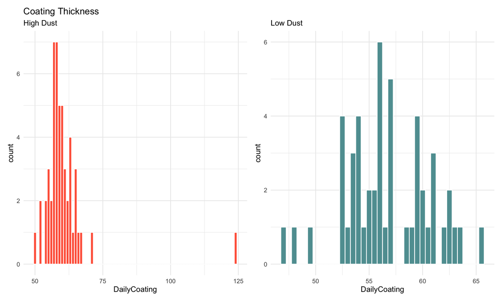

```r
HighDust_Coating <- ggplot(HighDust_SP2, aes(x = DailyCoating)) +
  geom_histogram(binwidth = 1, fill = "tomato", color = "white") +
  theme_minimal() +
  labs(title = "Coating Thickness",
       subtitle = "High Dust")


LowDust_Coating <- ggplot(LowDust_SP2, aes(x = DailyCoating)) +
  geom_histogram(binwidth = 0.5, fill = "cadetblue", color = "white") +
  theme_minimal()  +
  labs(subtitle = "Low Dust")


HighDust_Coating + LowDust_Coating
```

Coating thickness seems to follow a fairly normal distribution with one very high outlier in the high Dust category.

I can compare the mean and medians between high and low Dust events:

```r
# Means and medians
HighDust_CoatingSummary <- HighDust_SP2 %>%
  summarise(
    mean_high = mean(DailyCoating, na.rm = TRUE),
    median_high = median(DailyCoating, na.rm = TRUE)
  )

LowDust_CoatingSummary <- LowDust_SP2 %>%
  summarise(
    mean_low = mean(DailyCoating, na.rm = TRUE),
    median_low = median(DailyCoating, na.rm = TRUE)
  )

HighDust_CoatingSummary
```

```
## # A tibble: 1 × 2
##   mean_high median_high
##       <dbl>       <dbl>
## 1      60.5        58.7
```

```r
LowDust_CoatingSummary
```

```
## # A tibble: 1 × 2
##   mean_low median_low
##      <dbl>      <dbl>
## 1     56.7       56.2
```

Mean high: 60.47 Mean low: 56.70

Median high: 58.71 Median low: 56.19

The mean and median are higher during high events. This is what I would expect.

I will also run a wilcoxon test to determine if total mass differs significantly between high and low events:

```r
Dust_Wilcoxon_Coating <- wilcox.test(
  HighDust_SP2$DailyCoating,
  LowDust_SP2$DailyCoating,
  alternative = "two.sided"  # or "greater"/"less" if you expect direction
)

Dust_Wilcoxon_Coating
```

```
##
##  Wilcoxon rank sum test with continuity correction
##
## data:  HighDust_SP2$DailyCoating and LowDust_SP2$DailyCoating
## W = 1728, p-value = 0.002115
## alternative hypothesis: true location shift is not equal to 0
```

There IS a significant difference in the coating total between high and low Dust events (p < 0.01). The coating thickness is larger during high Dust events.

## ABF

*High ABF times*

```r
HighABF_SP2 <- DailySP2_NAAPS_Sfc %>%
  filter(ABFEvent == TRUE)
```

*Low ABF times*

```r
LowABF_SP2 <- DailySP2_NAAPS_Sfc %>%
  filter(ABFEvent == FALSE)
```

Then I will plot the four variables of interest during high and low ABF events: *Incandescent particle concentration*

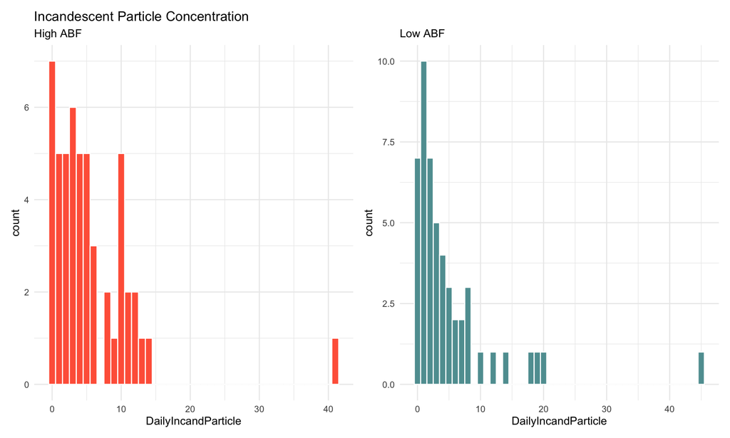

```r
HighABF_IncandPart <- ggplot(HighABF_SP2, aes(x = DailyIncandParticle)) +
  geom_histogram(binwidth = 1, fill = "tomato", color = "white") +
  theme_minimal() +
  labs(title = "Incandescent Particle Concentration",
       subtitle = "High ABF")


LowABF_IncandPart <- ggplot(LowABF_SP2, aes(x = DailyIncandParticle)) +
  geom_histogram(binwidth = 1, fill = "cadetblue", color = "white") +
  theme_minimal()  +
  labs(subtitle = "Low ABF")


HighABF_IncandPart + LowABF_IncandPart
```

The distributions look pretty similar.

I can compare the mean and medians between high and low ABF events:

```r
# Means and medians
HighABF_IncandSummary <- HighABF_SP2 %>%
  summarise(
    mean_high = mean(DailyIncandParticle, na.rm = TRUE),
    median_high = median(DailyIncandParticle, na.rm = TRUE)
  )

LowABF_IncandSummary <- LowABF_SP2 %>%
  summarise(
    mean_low = mean(DailyIncandParticle, na.rm = TRUE),
    median_low = median(DailyIncandParticle, na.rm = TRUE)
  )

HighABF_IncandSummary
```

```
## # A tibble: 1 × 2
##   mean_high median_high
##       <dbl>       <dbl>
## 1      5.63        4.20
```

```r
LowABF_IncandSummary
```

```
## # A tibble: 1 × 2
##   mean_low median_low
##      <dbl>      <dbl>
## 1     5.16       2.76
```

Mean high: 5.63 Mean low: 5.16

Median high: 4.20 Median low: 2.76

The mean and median are both higher during high events. This is what I would expect.

I will also run a wilcoxon test to determine if incandescent particle concentration differs significantly between high and low events:

```r
ABF_Wilcoxon_IncandParticle <- wilcox.test(
  HighABF_SP2$DailyIncandParticle,
  LowABF_SP2$DailyIncandParticle,
  alternative = "two.sided"  # or "greater"/"less" if you expect direction
)

ABF_Wilcoxon_IncandParticle
```

```
##
##  Wilcoxon rank sum test with continuity correction
##
## data:  HighABF_SP2$DailyIncandParticle and LowABF_SP2$DailyIncandParticle
## W = 1466, p-value = 0.1957
## alternative hypothesis: true location shift is not equal to 0
```

There is not a significant difference in incandescent particle concentration between high and low ABF deposition times.

*Incandescent Mass*

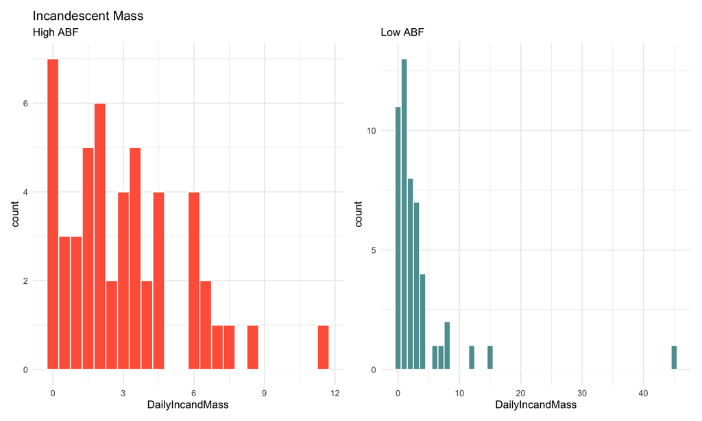

```r
HighABF_IncandMass <- ggplot(HighABF_SP2, aes(x = DailyIncandMass)) +
  geom_histogram(binwidth = 0.5, fill = "tomato", color = "white") +
  theme_minimal() +
  labs(title = "Incandescent Mass",
       subtitle = "High ABF")


LowABF_IncandMass <- ggplot(LowABF_SP2, aes(x = DailyIncandMass)) +
  geom_histogram(binwidth = 1, fill = "cadetblue", color = "white") +
  theme_minimal()  +
  labs(subtitle = "Low ABF")


HighABF_IncandMass + LowABF_IncandMass
```

The incandescent mass concentration looks pretty similar between high and low events as well. There is a really high outlier past 40 in the low ABF events.

I can compare the mean and medians between high and low ABF events:

```r
# Means and medians
HighABF_IncandMassSummary <- HighABF_SP2 %>%
  summarise(
    mean_high = mean(DailyIncandMass, na.rm = TRUE),
    median_high = median(DailyIncandMass, na.rm = TRUE)
  )

LowABF_IncandMassSummary <- LowABF_SP2 %>%
  summarise(
    mean_low = mean(DailyIncandMass, na.rm = TRUE),
    median_low = median(DailyIncandMass, na.rm = TRUE)
  )

HighABF_IncandMassSummary
```

```
## # A tibble: 1 × 2
##   mean_high median_high
##       <dbl>       <dbl>
## 1      3.06        2.65
```

```r
LowABF_IncandMassSummary
```

```
## # A tibble: 1 × 2
##   mean_low median_low
##      <dbl>      <dbl>
## 1     3.38       1.61
```

Mean high: 3.06 Mean low: 3.38

Median high: 2.64 Median low: 1.61

The mean is slightly higher during low events and the median is a bit higher during high events.

I will also run a wilcoxon test to determine if incandescent mass concentration differs significantly between high and low events:

```r
ABF_Wilcoxon_IncandMass <- wilcox.test(
  HighABF_SP2$DailyIncandMass,
  LowABF_SP2$DailyIncandMass,
  alternative = "two.sided"  # or "greater"/"less" if you expect direction
)

ABF_Wilcoxon_IncandMass
```

```
##
##  Wilcoxon rank sum test with continuity correction
##
## data:  HighABF_SP2$DailyIncandMass and LowABF_SP2$DailyIncandMass
## W = 1495, p-value = 0.136
## alternative hypothesis: true location shift is not equal to 0
```

There is not a significant difference in incandescent mass concentration between high and low ABF deposition times.

*Total Mass*

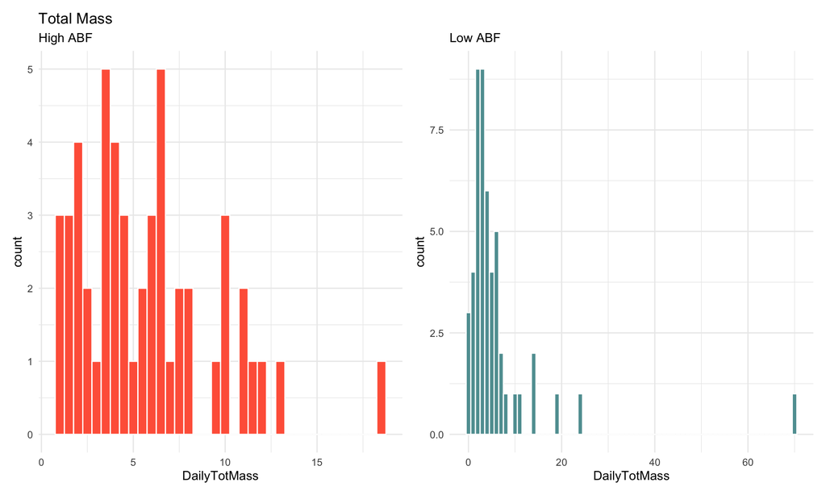

```r
HighABF_TotalMass <- ggplot(HighABF_SP2, aes(x = DailyTotMass)) +
  geom_histogram(binwidth = 0.5, fill = "tomato", color = "white") +
  theme_minimal() +
  labs(title = "Total Mass",
       subtitle = "High ABF")


LowABF_TotalMass <- ggplot(LowABF_SP2, aes(x = DailyTotMass)) +
  geom_histogram(binwidth = 1, fill = "cadetblue", color = "white") +
  theme_minimal()  +
  labs(subtitle = "Low ABF")


HighABF_TotalMass + LowABF_TotalMass
```

I can compare the mean and medians between high and low ABF events:

```r
# Means and medians
HighABF_TotalMassSummary <- HighABF_SP2 %>%
  summarise(
    mean_high = mean(DailyTotMass, na.rm = TRUE),
    median_high = median(DailyTotMass, na.rm = TRUE)
  )

LowABF_TotalMassSummary <- LowABF_SP2 %>%
  summarise(
    mean_low = mean(DailyTotMass, na.rm = TRUE),
    median_low = median(DailyTotMass, na.rm = TRUE)
  )

HighABF_TotalMassSummary
```

```
## # A tibble: 1 × 2
##   mean_high median_high
##       <dbl>       <dbl>
## 1      5.72        4.93
```

```r
LowABF_TotalMassSummary
```

```
## # A tibble: 1 × 2
##   mean_low median_low
##      <dbl>      <dbl>
## 1     6.13       3.53
```

Mean high: 5.71 Mean low: 6.13

Median high: 4.93 Median low: 3.52

The mean is higher during low events and the median is higher during high events.

I will also run a wilcoxon test to determine if total mass differs significantly between high and low events:

```r
ABF_Wilcoxon_TotMass <- wilcox.test(
  HighABF_SP2$DailyTotMass,
  LowABF_SP2$DailyTotMass,
  alternative = "two.sided"  # or "greater"/"less" if you expect direction
)

ABF_Wilcoxon_TotMass
```

```
##
##  Wilcoxon rank sum test with continuity correction
##
## data:  HighABF_SP2$DailyTotMass and LowABF_SP2$DailyTotMass
## W = 1549, p-value = 0.06321
## alternative hypothesis: true location shift is not equal to 0
```

There is a BORDERLINE significant difference in incandescent mass concentration between high and low ABF deposition times (p = 0.06).

*Coating Total*

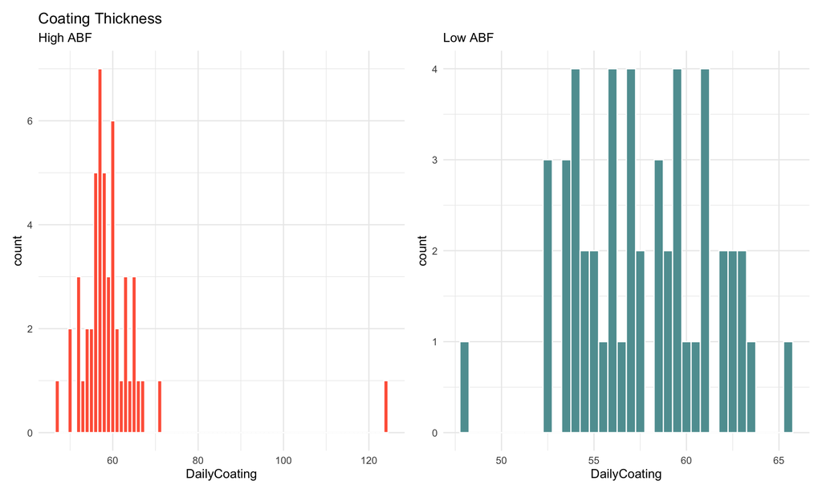

```r
HighABF_Coating <- ggplot(HighABF_SP2, aes(x = DailyCoating)) +
  geom_histogram(binwidth = 1, fill = "tomato", color = "white") +
  theme_minimal() +
  labs(title = "Coating Thickness",
       subtitle = "High ABF")


LowABF_Coating <- ggplot(LowABF_SP2, aes(x = DailyCoating)) +
  geom_histogram(binwidth = 0.5, fill = "cadetblue", color = "white") +
  theme_minimal()  +
  labs(subtitle = "Low ABF")


HighABF_Coating + LowABF_Coating
```

Coating thickness seems to follow a fairly normal distribution with one very high outlier in the high ABF category.

I can compare the mean and medians between high and low ABF events:

```r
# Means and medians
HighABF_CoatingSummary <- HighABF_SP2 %>%
  summarise(
    mean_high = mean(DailyCoating, na.rm = TRUE),
    median_high = median(DailyCoating, na.rm = TRUE)
  )

LowABF_CoatingSummary <- LowABF_SP2 %>%
  summarise(
    mean_low = mean(DailyCoating, na.rm = TRUE),
    median_low = median(DailyCoating, na.rm = TRUE)
  )

HighABF_CoatingSummary
```

```
## # A tibble: 1 × 2
##   mean_high median_high
##       <dbl>       <dbl>
## 1      59.6        57.9
```

```r
LowABF_CoatingSummary
```

```
## # A tibble: 1 × 2
##   mean_low median_low
##      <dbl>      <dbl>
## 1     57.6       57.2
```

Mean high: 59.58 Mean low: 57.60

Median high: 57.88 Median low: 57.18

The mean and median are higher during high events. This is what I would expect.

I will also run a wilcoxon test to determine if total mass differs significantly between high and low events:

```r
ABF_Wilcoxon_Coating <- wilcox.test(
  HighABF_SP2$DailyCoating,
  LowABF_SP2$DailyCoating,
  alternative = "two.sided"  # or "greater"/"less" if you expect direction
)

ABF_Wilcoxon_Coating
```

```
##
##  Wilcoxon rank sum test with continuity correction
##
## data:  HighABF_SP2$DailyCoating and LowABF_SP2$DailyCoating
## W = 1401, p-value = 0.394
## alternative hypothesis: true location shift is not equal to 0
```

There is not a significant difference in the coating total between high and low ABF events.

# Summary of Findings

There were significant differences in the coating thickness between high and low smoke events as well as dust events. There was a borderline significant difference in the total mass between high and low ABF events.